# Peer Assessment I

First, let us load the data and necessary packages:

```r
load("ames_train.Rdata")
library(MASS)
library(dplyr)
library(ggplot2)

library(devtools)
library(statsr)

library(lattice)
```

# 1

Make a labeled histogram (with 30 bins) of the ages of the houses in the data set, and describe the distribution.

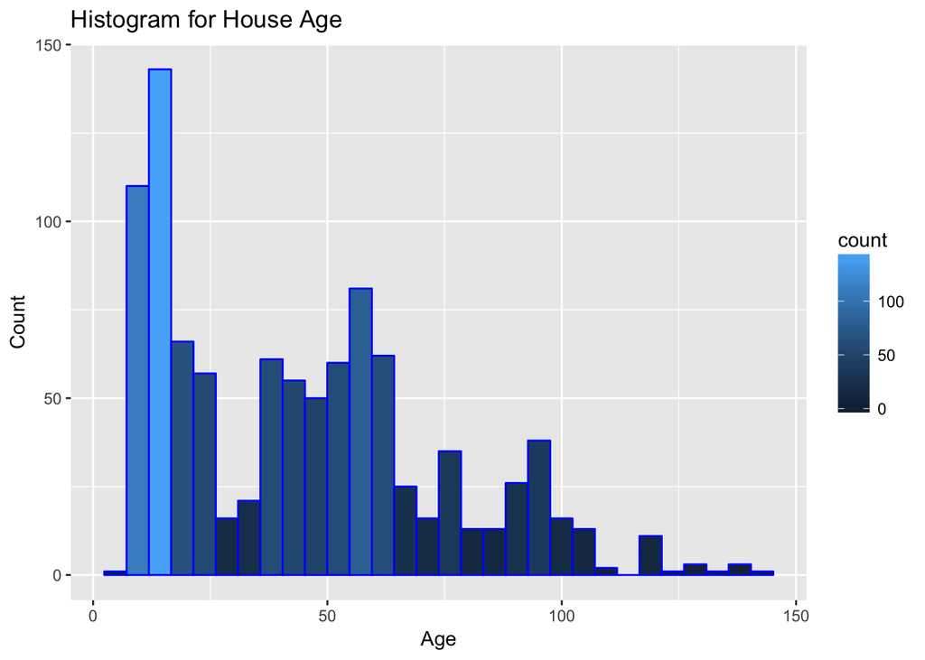

```r
current_year = as.numeric(format(Sys.Date(), "%Y"))

ames_train$Age = current_year - ames_train$Year.Built

ggplot(data = ames_train,aes(Age)) +
  geom_histogram( col="blue",
                 aes(fill=..count..),
                 bins=30) +
  labs(title="Histogram for House Age") +
  labs(x="Age", y="Count")
```

The distribution is **right skewed** and **asymmetric**. The **peaks** are clearly for newer houses. Also, there seem to be a **few potential outliers** at the very right.

We can see that there are very few older houses. As the age increases, the amount of houses goes down.

Although there’s an interesting point for houses between 25 and 35 years of age. The number of houses is around the same as houses between 65 and 100 years old.

# 2

The mantra in real estate is “Location, Location, Location!” Make a graphical display that relates a home price to its neighborhood in Ames, Iowa. Which summary statistics are most appropriate to use for determining the most expensive, least expensive, and most heterogeneous (having the most variation in housing price) neighborhoods? Report which neighborhoods these are based on the summary statistics of your choice. Report the value of your chosen summary statistics for these neighborhoods.

```r
summary(ames_train$Neighborhood)
```

```
## Blmngtn Blueste  BrDale BrkSide ClearCr CollgCr Crawfor Edwards Gilbert
##      11       3      10      41      13      85      29      60      49
##  Greens GrnHill  IDOTRR Landmrk MeadowV Mitchel   NAmes NoRidge NPkVill
##       4       2      35       0      16      44     155      28       4
## NridgHt  NWAmes OldTown  Sawyer SawyerW Somerst StoneBr   SWISU  Timber
##      57      41      71      61      46      74      20      12      19
## Veenker
##      10
```

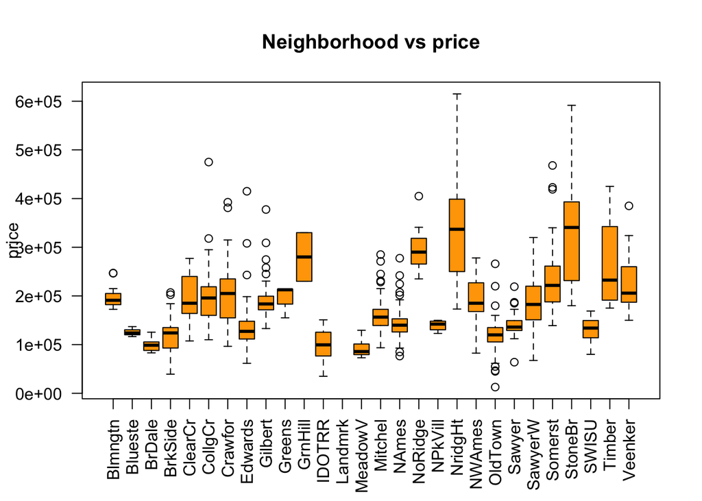

```r
boxplot(ames_train$price ~ ames_train$Neighborhood,
        col="orange",
        main="Neighborhood vs price",
        ylab="price",
        las=2)
```

```r
neighborhoods <- ames_train %>%
  group_by(Neighborhood)

price_m_sd = neighborhoods %>%
  group_by(Neighborhood) %>%
  summarise(mean=mean(price),
            sd=sd(price))

price_m_sd[order(price_m_sd$mean, decreasing = TRUE),]
```

```
## # A tibble: 27 × 3
##    Neighborhood     mean        sd
##          <fctr>    <dbl>     <dbl>
## 1       StoneBr 339316.0 123459.10
## 2       NridgHt 333646.7 105088.90
## 3       NoRidge 295844.6  35888.97
## 4       GrnHill 280000.0  70710.68
## 5        Timber 265192.2  84029.57
## 6       Somerst 234595.9  65199.49
## 7       Veenker 233650.0  72545.41
## 8       Crawfor 204196.6  71267.56
## 9       Blmngtn 198634.5  26454.86
## 10       Greens 198562.5  29063.42
## # ... with 17 more rows
```

```r
price_m_sd[order(price_m_sd$mean, decreasing = FALSE),]
```

```
## # A tibble: 27 × 3
##    Neighborhood      mean       sd
##          <fctr>     <dbl>    <dbl>
## 1       MeadowV  92946.88 18939.78
## 2        IDOTRR  97620.69 31530.44
## 3        BrDale  98930.00 13337.59
## 4       OldTown 120225.61 36429.69
## 5       BrkSide 122472.56 37309.91
## 6       Blueste 125800.00 10381.23
## 7         SWISU 130619.50 27375.76
## 8       Edwards 136322.02 54851.63
## 9       NPkVill 139275.00 11958.37
## 10       Sawyer 139312.70 21216.22
## # ... with 17 more rows
```

```r
price_median = neighborhoods %>%
  group_by(Neighborhood) %>%
  summarise(median=median(price))

price_median[order(price_median$median,decreasing = TRUE),]
```

```
## # A tibble: 27 × 2
##    Neighborhood   median
##          <fctr>    <dbl>
## 1       StoneBr 340691.5
## 2       NridgHt 336860.0
## 3       NoRidge 290000.0
## 4       GrnHill 280000.0
## 5        Timber 232500.0
## 6       Somerst 221650.0
## 7        Greens 212625.0
## 8       Veenker 205750.0
## 9       Crawfor 205000.0
## 10      CollgCr 195800.0
## # ... with 17 more rows
```

```r
price_median[order(price_median$median,decreasing = FALSE),]
```

```
## # A tibble: 27 × 2
##    Neighborhood median
##          <fctr>  <dbl>
## 1       MeadowV  85750
## 2        BrDale  98750
## 3        IDOTRR  99500
## 4       OldTown 120000
## 5       Blueste 123900
## 6       BrkSide 124000
## 7       Edwards 127250
## 8         SWISU 134000
## 9        Sawyer 136000
## 10        NAmes 139900
## # ... with 17 more rows
```

We decided to graph this data with a box plot in order to observer better the data by neighborhood.

And, we tried 2 sets of summary statistics: 1. Combination of mean and standard deviation and 2. Median.

Event though the lists were similar, it seems like **Median** would be the way to go. This was verified by comparing the results in the box plot. By sorting the neighborhood lists using the median price, we came to the conclusion that:

1. Most expensive neighborhood: **StoneBr**
2. Least expensive neighborhood: **MeadowV**
3. Most heterogenous neighborhood: **StoneBr**

# 3

Which variable has the largest number of missing values? Explain why it makes sense that there are so many missing values for this variable.

```r
naColumnTotals = sapply(ames_train, function(x) sum(is.na(x)))

sort(naColumnTotals[(naColumnTotals > 0)], decreasing = TRUE);
```

```
##        Pool.QC   Misc.Feature          Alley          Fence   Fireplace.Qu
##            997            971            933            798            491
##   Lot.Frontage  Garage.Yr.Blt    Garage.Qual    Garage.Cond    Garage.Type
##            167             48             47             47             46
##  Garage.Finish      Bsmt.Qual      Bsmt.Cond  Bsmt.Exposure BsmtFin.Type.1
##             46             21             21             21             21
## BsmtFin.Type.2   Mas.Vnr.Area   BsmtFin.SF.1   BsmtFin.SF.2    Bsmt.Unf.SF
##             21              7              1              1              1
##  Total.Bsmt.SF Bsmt.Full.Bath Bsmt.Half.Bath    Garage.Cars    Garage.Area
##              1              1              1              1              1
```

```r
count(ames_train, 'Pool.Area')
```

```
## # A tibble: 1 × 2
##   `"Pool.Area"`     n
##           <chr> <int>
## 1     Pool.Area  1000
```

By getting the total **NA** values for each variable we found out that the variable with the largest number of missing values is **Pool Quality**.

# 4

We want to predict the natural log of the home prices. Candidate explanatory variables are lot size in square feet (Lot.Area), slope of property (Land.Slope), original construction date (Year.Built), remodel date (Year.Remod.Add), and the number of bedrooms above grade (Bedroom.AbvGr). Pick a model selection or model averaging method covered in the Specialization, and describe how this method works. Then, use this method to find the best multiple regression model for predicting the natural log of the home prices.

```r
price_pred_model_lot_area = lm(log(price) ~ Lot.Area + Land.Slope + Year.Built + Year.Remod.Add + Bedroom.AbvGr, data = ames_train)

summary(price_pred_model_lot_area)
```

```
##
## Call:
## lm(formula = log(price) ~ Lot.Area + Land.Slope + Year.Built +
##     Year.Remod.Add + Bedroom.AbvGr, data = ames_train)
##
## Residuals:
##     Min      1Q  Median      3Q     Max
## -2.0878 -0.1651 -0.0211  0.1657  0.9945
##
## Coefficients:
##                  Estimate Std. Error t value Pr(>|t|)
## (Intercept)    -1.371e+01  8.574e-01 -15.996  < 2e-16 ***
## Lot.Area        1.028e-05  1.106e-06   9.296  < 2e-16 ***
## Land.SlopeMod   1.384e-01  4.991e-02   2.773  0.00565 **
## Land.SlopeSev  -4.567e-01  1.514e-01  -3.016  0.00263 **
## Year.Built      6.049e-03  3.788e-04  15.968  < 2e-16 ***
## Year.Remod.Add  6.778e-03  5.468e-04  12.395  < 2e-16 ***
## Bedroom.AbvGr   8.686e-02  1.077e-02   8.063 2.12e-15 ***
## ---
## Signif. codes:  0 '***' 0.001 '**' 0.01 '*' 0.05 '.' 0.1 ' ' 1
##
## Residual standard error: 0.279 on 993 degrees of freedom
## Multiple R-squared:  0.5625, Adjusted R-squared:  0.5598
## F-statistic: 212.8 on 6 and 993 DF,  p-value: < 2.2e-16
```

```r
step <- stepAIC(price_pred_model_lot_area, direction="backward", k=log(1000))
```

```
## Start:  AIC=-2511.42
## log(price) ~ Lot.Area + Land.Slope + Year.Built + Year.Remod.Add +
##     Bedroom.AbvGr
##
##                  Df Sum of Sq    RSS     AIC
## <none>                        77.322 -2511.4
## - Land.Slope      2    1.4281 78.750 -2506.9
## - Bedroom.AbvGr   1    5.0628 82.385 -2454.9
## - Lot.Area        1    6.7292 84.051 -2434.9
## - Year.Remod.Add  1   11.9642 89.286 -2374.5
## - Year.Built      1   19.8546 97.177 -2289.8
```

```r
final_price_pred_model_lot_area = lm(log(price) ~ Lot.Area + Land.Slope + Year.Built + Year.Remod.Add + Bedroom.AbvGr, data = ames_train)
```

To find the best model, we used stepwise model selection by AIC. A process we could do manually, but the **stepAIC** function will do it for us.

By using this technique we found out that that all the variables selected are strong predictors for the **natural log of the home prices**. So the final model includes all varaibles:

**1. Lot.Area** **2. Land.Slope** **3. Year.Built** **4. Year.Remod.Add** **5. Bedroom.AbvGr**

# 5

Which home has the largest squared residual in the previous analysis (Question 4)? Looking at all the variables in the data set, can you explain why this home stands out from the rest (what factors contribute to the high squared residual and why are those factors relevant)?

```r
price_squared_residuals <- final_price_pred_model_lot_area$residuals^2

outlier <- head(ames_train[with(ames_train,
                                order(price_squared_residuals,
                                      decreasing = TRUE)
                                ),
                           ],1)

outlier$PID
```

```
## [1] 902207130
```

```r
outlier$Neighborhood
```

```
## [1] OldTown
## 28 Levels: Blmngtn Blueste BrDale BrkSide ClearCr CollgCr ... Veenker
```

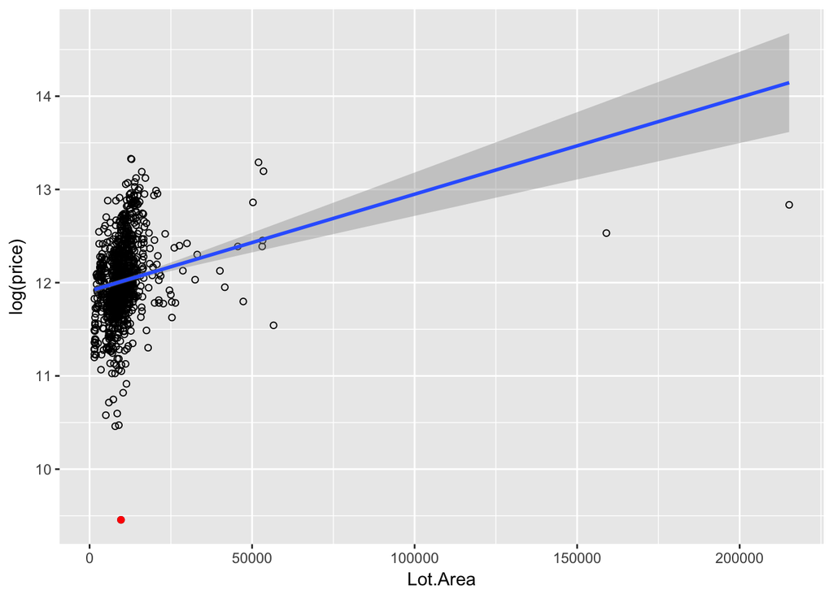

```r
outlier_neighborhood = neighborhoods %>%
            filter(Neighborhood == outlier$Neighborhood)

ggplot(data=ames_train, aes(x=Lot.Area, y=log(price))) +
  geom_point(shape=1) +
  geom_smooth(method=lm) +
  geom_point(data=outlier,
             aes(x=Lot.Area,
                 y=log(price)),
             color="Red")
```

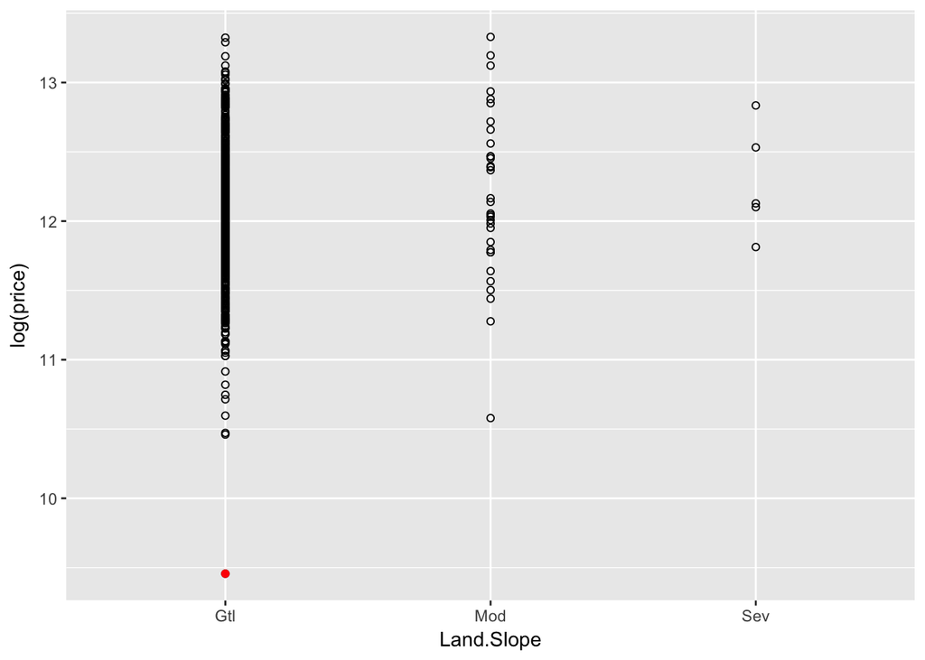

```r
ggplot(data=ames_train, aes(x=Land.Slope, y=log(price))) +
  geom_point(shape=1) +
  geom_smooth(method=lm) +
  geom_point(data=outlier,
             aes(x=Land.Slope,
                 y=log(price)),
             color="Red")
```

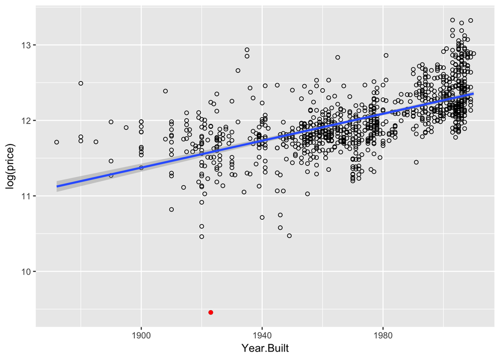

```r
ggplot(data=ames_train, aes(x=Year.Built, y=log(price))) +
  geom_point(shape=1) +
  geom_smooth(method=lm) +
  geom_point(data=outlier,
             aes(x=Year.Built,
                 y=log(price)),
             color="Red")
```

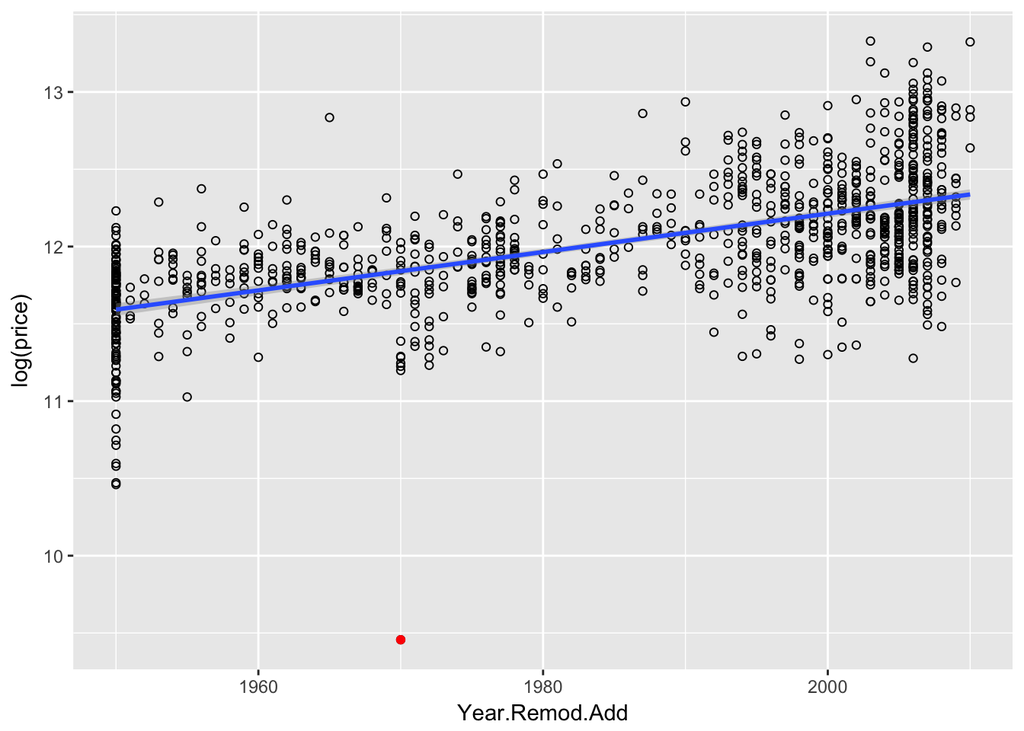

```r
ggplot(data=ames_train, aes(x=Year.Remod.Add, y=log(price))) +
  geom_point(shape=1) +
  geom_smooth(method=lm) +
  geom_point(data=outlier,
             aes(x=Year.Remod.Add,
                 y=log(price)),
             color="Red")
```

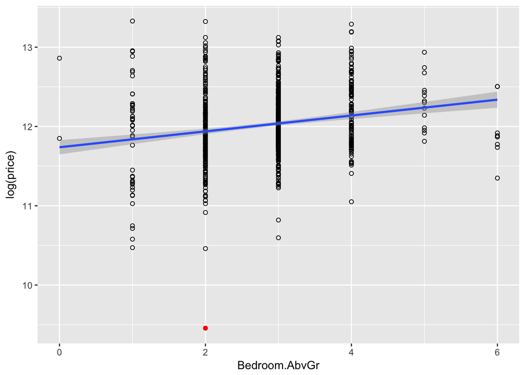

```r
ggplot(data=ames_train, aes(x=Bedroom.AbvGr, y=log(price))) +
  geom_point(shape=1) +
  geom_smooth(method=lm) +
  geom_point(data=outlier,
             aes(x=Bedroom.AbvGr,
                 y=log(price)),
             color="Red")
```

```r
summary(neighborhoods$price)
```

```
##    Min. 1st Qu.  Median    Mean 3rd Qu.    Max.
##   12790  129800  159500  181200  213000  615000
```

We can see the red dot is the same one for each graph.

The home with the largest squared residual is the one that has **PID = 902207130**. This home is inside the **OldTown** neighborhood.

After looking at the variables in the dataset **the only factor that stands out is the price**. This home is the **lowest priced** in the neighborhood. Not only it is the lowest, but it’s far from the median.

# 6

Use the same model selection method you chose in Question 4 to again find the best multiple regression model to predict the natural log of home prices, but this time **replacing Lot.Area with log(Lot.Area)**. Do you arrive at a model including the same set of predictors?

```r
price_pred_model_log_lot_area = lm(log(price) ~ log(Lot.Area) +
                                     Land.Slope +
                                     Year.Built +
                                     Year.Remod.Add +
                                     Bedroom.AbvGr,
                                   data = ames_train)

summary(price_pred_model_log_lot_area)
```

```
##
## Call:
## lm(formula = log(price) ~ log(Lot.Area) + Land.Slope + Year.Built +
##     Year.Remod.Add + Bedroom.AbvGr, data = ames_train)
##
## Residuals:
##      Min       1Q   Median       3Q      Max
## -2.14050 -0.15650 -0.01561  0.15350  0.90854
##
## Coefficients:
##                  Estimate Std. Error t value Pr(>|t|)
## (Intercept)    -1.553e+01  8.197e-01 -18.947  < 2e-16 ***
## log(Lot.Area)   2.442e-01  1.708e-02  14.297  < 2e-16 ***
## Land.SlopeMod   1.151e-01  4.734e-02   2.431   0.0152 *
## Land.SlopeSev  -6.554e-02  1.222e-01  -0.536   0.5917
## Year.Built      5.981e-03  3.597e-04  16.628  < 2e-16 ***
## Year.Remod.Add  6.734e-03  5.190e-04  12.975  < 2e-16 ***
## Bedroom.AbvGr   5.909e-02  1.055e-02   5.599  2.8e-08 ***
## ---
## Signif. codes:  0 '***' 0.001 '**' 0.01 '*' 0.05 '.' 0.1 ' ' 1
##
## Residual standard error: 0.2649 on 993 degrees of freedom
## Multiple R-squared:  0.6056, Adjusted R-squared:  0.6032
## F-statistic: 254.1 on 6 and 993 DF,  p-value: < 2.2e-16
```

```r
step <- stepAIC(price_pred_model_log_lot_area, direction="backward", k=log(1000))
```

```
## Start:  AIC=-2615.14
## log(price) ~ log(Lot.Area) + Land.Slope + Year.Built + Year.Remod.Add +
##     Bedroom.AbvGr
##
##                  Df Sum of Sq    RSS     AIC
## - Land.Slope      2    0.4429 70.147 -2622.6
## <none>                        69.704 -2615.1
## - Bedroom.AbvGr   1    2.2002 71.904 -2591.0
## - Year.Remod.Add  1   11.8182 81.522 -2465.4
## - log(Lot.Area)   1   14.3474 84.051 -2434.9
## - Year.Built      1   19.4083 89.112 -2376.4
##
## Step:  AIC=-2622.62
## log(price) ~ log(Lot.Area) + Year.Built + Year.Remod.Add + Bedroom.AbvGr
##
##                  Df Sum of Sq    RSS     AIC
## <none>                        70.147 -2622.6
## - Bedroom.AbvGr   1    2.0816 72.228 -2600.3
## - Year.Remod.Add  1   11.9455 82.092 -2472.3
## - log(Lot.Area)   1   15.7256 85.872 -2427.3
## - Year.Built      1   19.3032 89.450 -2386.4
```

```r
final_price_pred_model_log_lot_area = lm(log(price) ~ log(Lot.Area) +
                                           Year.Built +
                                           Year.Remod.Add +
                                           Bedroom.AbvGr,
                                         data = ames_train)
```

By **replacing Lot.Area with log(Lot.Area)** and using the same model selection method from Question 4, the resulting model is **different**. It removes 1 variable: **Land.Slope**. So the resulting model has the following variable:

1. **Bedroom.AbvGr**
2. **Year.Remod.Add**
3. **log(Lot.Area)**
4. **Year.Built**

# 7

Do you think it is better to log transform Lot.Area, in terms of assumptions for linear regression? Make graphs of the predicted values of log home price versus the true values of log home price for the regression models selected for Lot.Area and log(Lot.Area). Referencing these two plots, provide a written support that includes a quantitative justification for your answer in the first part of question 7.

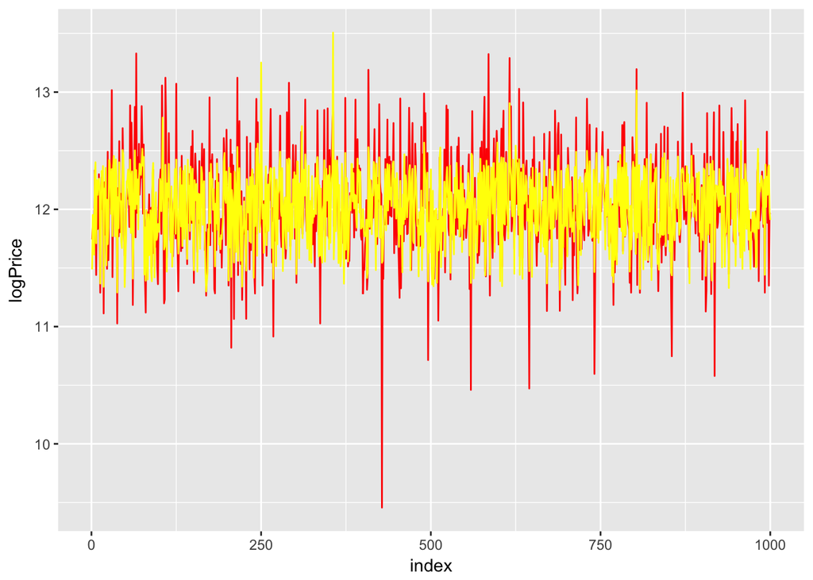

```r
price_data_set = data.frame(
   index = seq.int(nrow(ames_train)),
  logPrice = log(ames_train$price),
  priceLotArea = final_price_pred_model_lot_area$fitted.values,
  priceLogLotArea = final_price_pred_model_log_lot_area$fitted.values,
  logPMinusLotArea = log(ames_train$price) - final_price_pred_model_lot_area$fitted.values,
  logPMinusLogLotArea = log(ames_train$price) - final_price_pred_model_log_lot_area$fitted.values
)

ggplot(price_data_set, aes(index)) +
  geom_line(aes(y=logPrice), colour="red") +
  geom_line(aes(y=priceLotArea), colour="yellow")
```

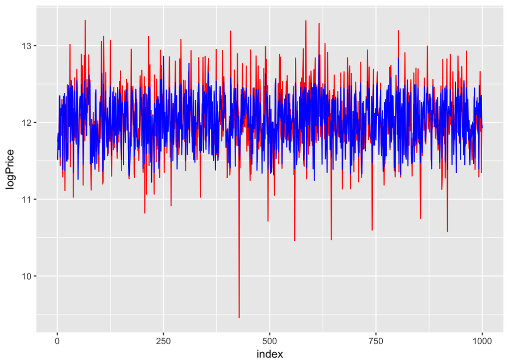

```r
ggplot(price_data_set, aes(index)) +
  geom_line(aes(y=logPrice), colour="red") +
  geom_line(aes(y=priceLogLotArea), colour="blue")
```

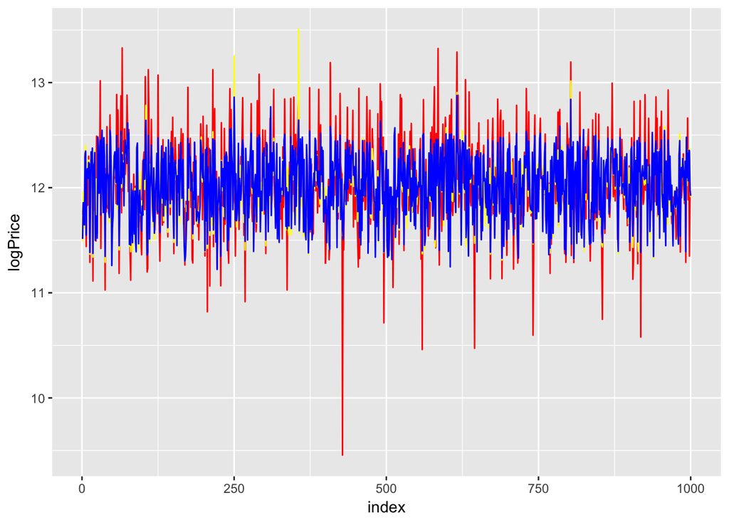

```r
ggplot(price_data_set, aes(index)) +
  geom_line(aes(y=logPrice), colour="red") +
  geom_line(aes(y=priceLotArea), colour="yellow") +
  geom_line(aes(y=priceLogLotArea), colour="blue")
```

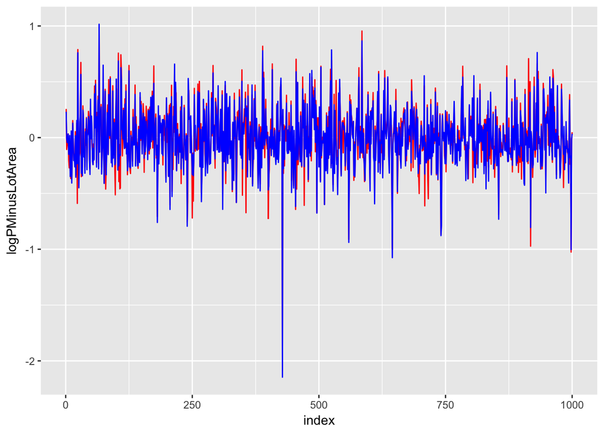

```r
ggplot(price_data_set, aes(index)) +
  geom_line(aes(y=logPMinusLotArea), colour="red") +
  geom_line(aes(y=logPMinusLogLotArea), colour="blue")
```

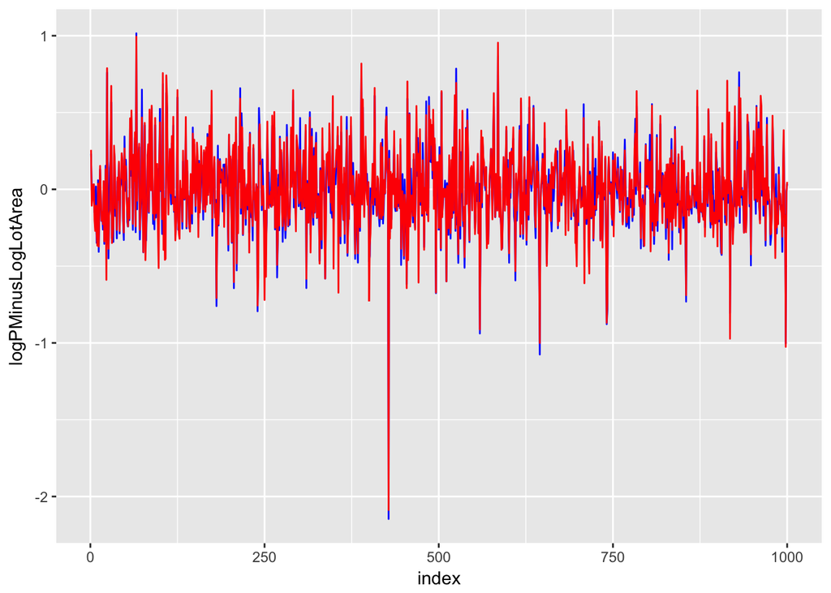

```r
ggplot(price_data_set, aes(index)) +
  geom_line(aes(y=logPMinusLogLotArea), colour="blue") +
  geom_line(aes(y=logPMinusLotArea), colour="red")
```

We created a data set with 6 variables:

1. **index**: a sequential index to use as reference
2. **logPrice**: The **actual** values for log(price)
3. **priceLotArea**: The **predicted** values for log(price) using the model that includes the Lot.Area variable.
4. **priceLogLotArea**: The **predicted** values for log(price) using the model that includes the log(Lot.Area) variable.
5. **logPMinusLotArea**: The difference between the **actual** log(price) values and the **predicted** values for log(price) using the model that includes the Lot.Area variable.
6. **logPMinusLogLotArea**: The difference between the **actual** log(price) values and the **predicted** values for log(price) using the model that includes the log(Lot.Area) variable.

To visualize the differences between 3 and 4, we made 3 graphs:

First graph includes 2 and 3. Second graph includes 2 and 4. Third graph includes 2,3 and 4.

But, we couldn’t really tell if there’s a clear between 3 and 4. So we plotted the differences between the **actual** values and the **predicted** values. For this we did 2 graphs, which are essentially the same one, but they differ in which variable is on top:

### 7.0.1